# Comparison of K-Nearest Neighbours, Decision Tree and Logistic Regression on Iris Plants Dataset

# 1 Aim

This project report conduct and compare the performance of three different machine learning classification algorithms, specifically K-Nearest Neighbours, Decision Tree and Logistic Regression on scikit-learn's Iris Plants dataset, aiming to provide insights on which algorithm is more suitable for the task.

# 2 Data Preparation

### Load Dataset

Firstly, we load the Iris plants dataset from scikit-learn and check out the dataset we are working with.

```python
from sklearn.datasets import load_iris

# Load dataset
data = load_iris()
X = data.data
y = data.target
```

Run the code below to see the data points features values(X) and their labels(y):

```python
# print(X)
# print(y)
```

### Split Dataset into Train and Test Sets

Then, we split the data points features values and their labels into train set and test set. Train : Test split ratio is typically 8:2. Hence, the train set will take up 80% of the total dataset, while the test set will take up the remaning dataset (20%). The purpose of the train set is to train the classification machine learning model on known data and the test set is to evaluate the performance of our trained model on unseen data.

```python
from sklearn.model_selection import train_test_split

# Split the data into train set (80%) and test set (20%)
X_train, X_test, y_train, y_test = train_test_split(X, y, test_size=0.2, random_state=42, stratify=y)
```

Run the code below to check the number of data in each set:

```python
# Check size of the sets
print('Data in train set:', len(X_train))
print('Data in test set:', len(X_test))
```

```
Data in train set: 120
Data in test set: 30
```

### Feature Scaling

Next, we will be applying feature scaling on the Iris plants dataset since KNN uses distance calculations in its algorithm to find its nearest neighbours. This can lead to a more accurate classifier model and results. Unlike K-Nearest Neighbours, Decision tree classification's performance is not affected by the feature's distances and therefore do not need feature scaling. However, to ensure a fair comparison, we will apply feature scaling for the dataset and use it for all classification algorithms in this project.

```python
from sklearn.preprocessing import StandardScaler

# Initialize StandardScalar
sScaler = StandardScaler()

# Fit scalar to train set and then transform all the data sets
sScaler.fit(X_train)
data_scaled = sScaler.transform(X)
X_train_scaled = sScaler.transform(X_train)
X_test_scaled = sScaler.transform(X_test)
```

#### t-SNE

Let's take a look at our data with the scaled features now. We can visualise the data in a lower-dimensional space using t-Distributed Stochastic Neighbor Embedding (t-SNE).

```
[t-SNE] Computing 119 nearest neighbors...
[t-SNE] Indexed 120 samples in 0.000s...
[t-SNE] Computed neighbors for 120 samples in 0.184s...
[t-SNE] Computed conditional probabilities for sample 120 / 120
[t-SNE] Mean sigma: 1.053548
[t-SNE] KL divergence after 250 iterations with early exaggeration: 43.738312
[t-SNE] KL divergence after 300 iterations: 0.088651
```

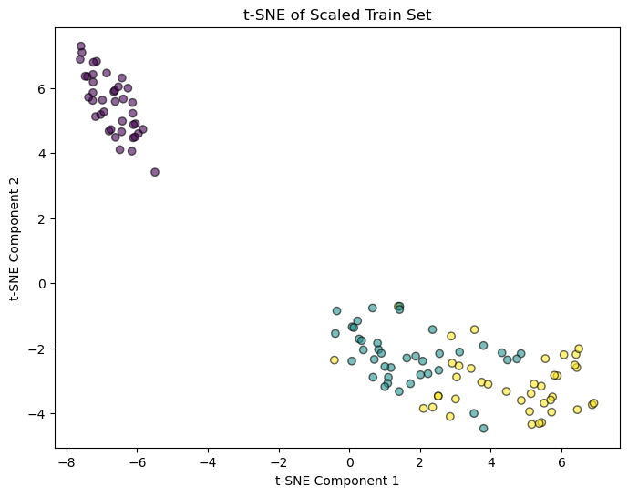

```python
from sklearn.manifold import TSNE
import matplotlib.pyplot as plt

# Initialise t-SNE and its parameters
tsne = TSNE(n_components=2, verbose=1, perplexity=40, n_iter=300)

# Apply t-SNE to scaled train set
tsne_train_scaled = tsne.fit_transform(X_train_scaled)

# Plot t-SNE dataset
plt.figure(figsize=(8, 6))
plt.scatter(tsne_train_scaled[:, 0], tsne_train_scaled[:, 1], c=y_train, cmap='viridis', edgecolor='k', alpha=0.6)
plt.title('t-SNE of Scaled Train Set')
plt.xlabel('t-SNE Component 1')
plt.ylabel('t-SNE Component 2')

plt.show()
```

# 3 Exploratory Data Analysis (EDA)

Now, let's explore and understand the Iris plants data that we are working with, particularly about the statistics of the feature it contains.

### Summary Statistics of Each Feature

```python
import pandas as pd

# Get pandas dataframe of iris plants dataset
df = pd.DataFrame(data=data_scaled, columns=data.feature_names)
df['species'] = y

# Get summary statistics of each feature
summary_stats = df.describe()
print(summary_stats)
```

```
       sepal length (cm)  sepal width (cm)  petal length (cm)  \
count         150.000000        150.000000         150.000000
mean            0.001990          0.020150          -0.006814
std             0.988836          0.975854           1.002363
min            -1.840983         -2.347097          -1.572848
25%            -0.885662         -0.555990          -1.232159
50%            -0.049756         -0.108213           0.329333
75%             0.666734          0.563452           0.755194
max             2.457961          3.026225           1.777262

       petal width (cm)     species
count        150.000000  150.000000
mean          -0.007461    1.000000
std            1.003632    0.819232
min           -1.454945    0.000000
25%           -1.191606    0.000000
50%            0.125086    1.000000
75%            0.783432    2.000000
max            1.705116    2.000000
```

### Visualise the data using visualisation techniques

```python
# Import the necessary libraries
import matplotlib.pyplot as plt
import seaborn as sns
```

In the code below, we plot and visualise the histogram of each feature in our dataset.

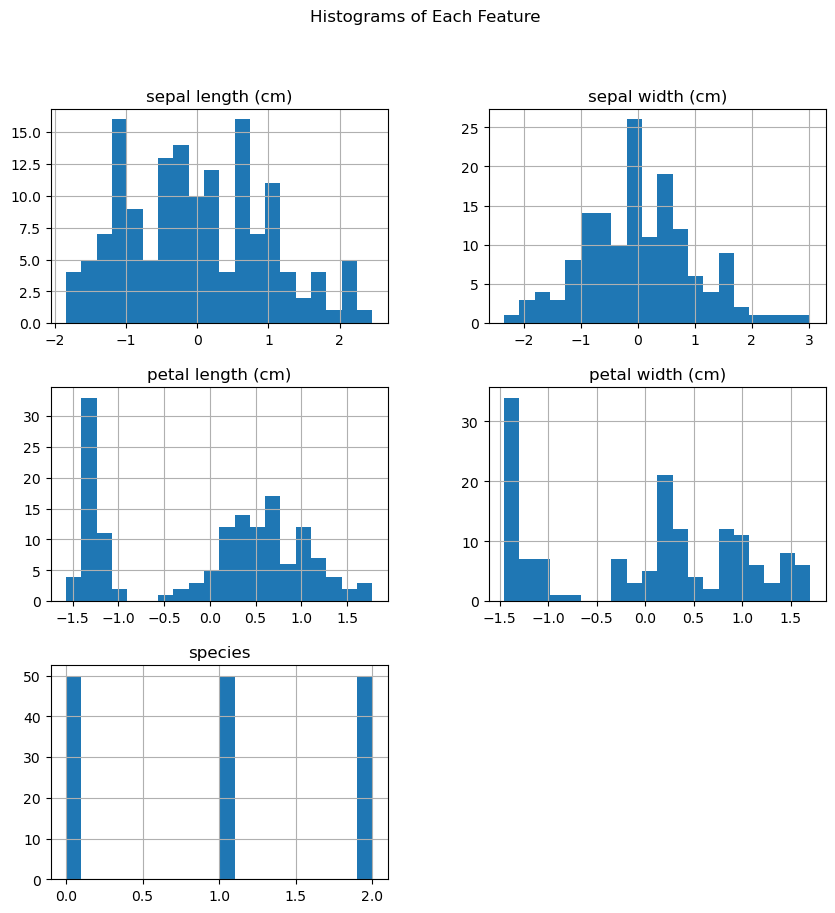

```python
df.hist(bins=20, figsize=(10, 10))
plt.suptitle("Histograms of Each Feature")
plt.show()
```

Next, let's visualise the relationship between features using a pairplot.

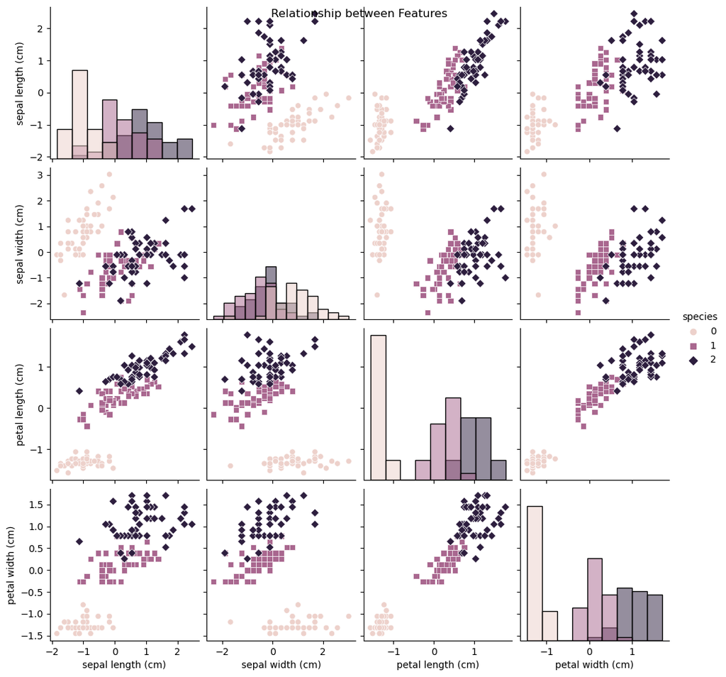

```python
sns.pairplot(df, hue='species', markers=["o", "s", "D"], diag_kind='hist')
plt.suptitle("Relationship between Features")
plt.show()
```

From the pairplot, we can see that species 0 (setosa)'s features' magnitudes are further compared to species 1 (versicolor) and 2 (virginica). Below, we plot a correlation matrix to consolidate the data above.

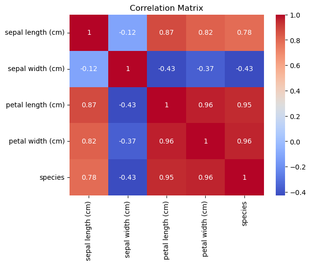

```python
matrix = df.corr()
sns.heatmap(matrix, annot=True, cmap='coolwarm')
plt.title("Correlation Matrix")
plt.show()
```

# 4 K-Nearest Neighbours

## 4.1 K-Nearest Neighbours Custom Implementation

Now, let's build our custom KNN classifer model.

**Implementation**  
We want to design our algorithm in a way that follows scikit-learn's conventions so that we can use their tools and modules provided. This means that we have to include their necessary libraries 'BaseEstimator' and 'ClassifierMixin', as well as implement certain methods like 'fit' and 'predict' in our algorithm.

**Algorithm**  
The following are the steps we are taking to implement the KNN prediction algorithm:

1. Calculate distances between train set points and new points
2. Sort distances
3. Get labels of k nearest neighbors
4. Perform majority vote
5. Determine class predictions

```python
from sklearn.base import BaseEstimator, ClassifierMixin
from sklearn.metrics import pairwise_distances
from collections import Counter
import numpy as np

class CustomKNNClassifier(BaseEstimator, ClassifierMixin):
    def __init__(self, k=5, distance_metric='euclidean'):
        self.k = k
        self.distance_metric = distance_metric

    def fit(self, X, y):
        self.X_train_ = X
        self.y_train_ = y
        return self

    def predict(self, X):
        predictions = []
        for point in X:
            # Calculate distances
            distances = pairwise_distances(self.X_train_, [point], metric=self.distance_metric).ravel()

            # Sort distances
            k_nearest_indices = np.argsort(distances)[:self.k]

            # Get labels of k nearest neighbors
            k_nearest_labels = self.y_train_[k_nearest_indices]

            # Perform majority vote
            majority_label = Counter(k_nearest_labels).most_common(1)

            # Determine class predictions
            predicted_class = majority_label[0][0]
            predictions.append(predicted_class)

        # Return list of points class predictions
        return np.array(predictions)
```

After building our custom KNN classifier model, now let's train it.

```python
# Define k and distance metric
k = 5
distance_metric = 'euclidean'

# Create an instance of CustomKNNClassifier
customKNN = CustomKNNClassifier(k, distance_metric)

# Fit the model on train set
customKNN.fit(X_train_scaled, y_train)

# Predict the train set
predictions = customKNN.predict(X_train_scaled)

# Print the predictions
print(predictions)
```

```
[0 1 1 0 1 2 1 2 2 2 2 1 1 1 1 0 0 2 2 0 1 0 2 0 1 2 2 0 2 0 0 1 1 0 2 2 1
 1 2 1 0 1 0 2 0 0 2 0 0 0 0 1 2 1 0 2 1 2 0 2 0 1 2 0 2 1 2 1 1 2 0 0 0 1
 1 2 1 2 2 1 0 2 1 0 2 0 2 1 1 0 1 2 0 0 2 2 2 1 2 0 2 1 2 2 0 1 1 1 1 1 0
 2 1 1 0 0 0 0 1 0]
```

## 4.2 Hyperparameter Tuning

Next, let's find the hyperparameter that makes a KNN learning machine model that produces the most accurate results. We will find the best hyperparameters by using scikit-learn's Grid Search, utilising cross validation method in the process as our iris plants dataset is small.

```python
from sklearn.model_selection import GridSearchCV

# Define list of hyperparameter values to test
param_grid = {
    'k': [3, 5, 7, 9, 11],
    'distance_metric': ['euclidean', 'manhattan', 'chebyshev', 'minkowski']
}

# Perform grid search and fitting
grid_search = GridSearchCV(estimator=CustomKNNClassifier(), param_grid=param_grid, cv=5, scoring='accuracy', n_jobs=-1, verbose=1)
grid_search.fit(X_train_scaled, y_train)

# Print best hyperparameters
print(f'Best hyperparameters: {grid_search.best_params_}')
```

```
Fitting 5 folds for each of 20 candidates, totalling 100 fits
Best hyperparameters: {'distance_metric': 'euclidean', 'k': 3}
```

From the results, we can see that the best hyperparameters for the most accurate KNN learning machine model is k = 3 and distance_metric = euclidean.

## 4.3 Evaluation

Now, let's test our trained custom KNN classification machine learning model on the test set to see how well it performs on unseen dataset.

```python
# Initialise 'k' value and distance metric (best hyperparameters)
k = 3
distance_metric = 'euclidean'

# Create instance of CustomKNNClassifier
customKNN = CustomKNNClassifier(k, distance_metric)

# Fit model on train set
customKNN.fit(X_train_scaled, y_train)

# Predict the test set
predictions = customKNN.predict(X_test_scaled)
```

Let's use a confusion matrix to provide us a summary of the performance of our CustomKNNClassifier on the Iris Plants scaled test dataset, taking a look at its accuracy, precision, recall and F1 score.

```
Test Set Accuracy: 0.9333
Test Set Precision: 0.9444
Test Set Recall: 0.9333
Test set F1 score: 0.9327
```

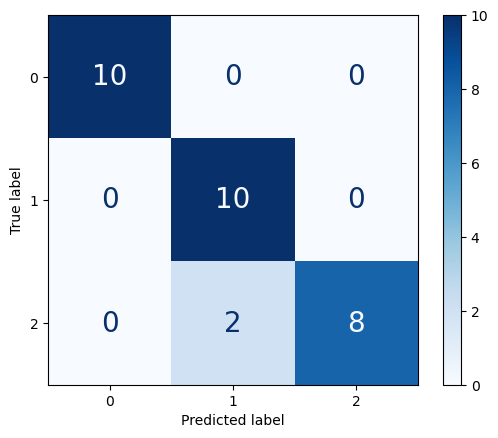

```python
from sklearn.metrics import confusion_matrix, ConfusionMatrixDisplay
from sklearn.metrics import accuracy_score, precision_score, recall_score, f1_score

# Generate confusion matrix
ax = ConfusionMatrixDisplay.from_predictions(y_test, predictions, cmap='Blues')

# Set confusion matrix text size
for data_point in ax.text_.ravel():
    data_point.set_fontsize(20)

# Calculate and display accuracy, precision, recall and f1 score
knn_accuracy = accuracy_score(y_test, predictions)
knn_precision = precision_score(y_test, predictions, average='macro')
knn_recall = recall_score(y_test, predictions, average='macro')
knn_f1 = f1_score(y_test, predictions, average='macro')

# Print the results
print(f'Test Set Accuracy: {knn_accuracy:.4f}')
print(f'Test Set Precision: {knn_precision:.4f}')
print(f'Test Set Recall: {knn_recall:.4f}')
print(f'Test set F1 score: {knn_f1:.4f}')
```

# 5 Decision Tree

## 5.1 Decision Tree Implementation

We will be using scikit-learn's DecisionTreeClassifier to fit, train and predict the classification for our Iris plants dataset.

```python
from sklearn.tree import DecisionTreeClassifier
import pandas as pd
import numpy as np

model = DecisionTreeClassifier(random_state=42)
model.fit(X_train_scaled, y_train)
train_predictions = model.predict(X_train_scaled)
print(train_predictions)
```

```
[0 2 1 0 1 2 1 2 2 2 2 1 1 1 1 0 0 2 2 0 1 0 2 0 1 2 2 0 2 0 0 1 1 0 2 2 1
 1 2 1 0 1 0 2 0 0 2 0 0 0 0 1 2 1 0 2 1 2 0 2 0 1 2 0 1 1 2 1 1 2 0 0 0 2
 1 2 1 2 2 1 0 2 1 0 2 0 2 1 1 0 1 2 0 0 2 2 2 1 2 0 2 1 2 2 0 1 1 1 1 1 0
 2 1 1 0 0 0 0 1 0]
```

## 5.2 Hyperparameter Tuning

Next, let's find the hyperparameter that makes a Decision Tree learning machine model that produces the most accurate results. We will find the best hyperparameters by using scikit-learn's Grid Search, utilising cross validation method in the process as our iris plants dataset is small.

```python
from sklearn.model_selection import GridSearchCV

# Define list of hyperparameter values to test
param_grid = {
    'max_depth': [None, 2, 4, 6, 8, 10, 12],
    'min_samples_split': [2, 5, 10, 20, 30]
}

# Perform grid search and fitting
grid_search = GridSearchCV(estimator=model, param_grid=param_grid, cv=5, scoring='accuracy', n_jobs=-1)
grid_search.fit(X_train_scaled, y_train)

# Print best hyperparameters and cross validation accuracy
print(f'Best hyperparameters: {grid_search.best_params_}')
print(f'Best cross validation accuracy: {grid_search.best_score_:.4f}')
```

```
Best hyperparameters: {'max_depth': None, 'min_samples_split': 2}
Best cross validation accuracy: 0.9417
```

From the results, we can see that the best hyperparameters for the most accurate Decision Tree learning machine model is max_depth = none and min_samples_split = 2. Using these hyperparameters, the accuracy of the decision tree learning model on the iris plants train dataset is 0.9417.

## 5.3 Evaluation

Now, let's test our trained decision tree learning machine model with the best hyperparameters on the iris plants test dataset to see how it performs. We will evaluate the performace using confusion matrix and the following metrics: accuracy, precision, recall and F1 score.

```
Test set accuracy: 0.9333
Test set precision: 0.9333
Test set recall: 0.9333
Test set F1 score: 0.9333
```

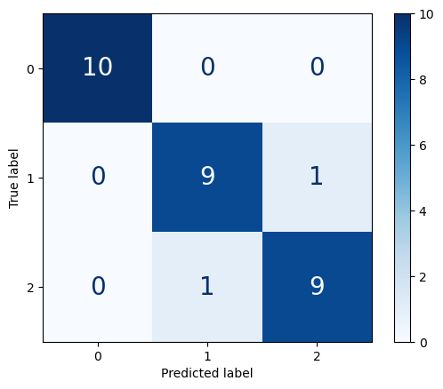

```python
from sklearn.metrics import confusion_matrix, ConfusionMatrixDisplay
from sklearn.metrics import accuracy_score, precision_score, recall_score, f1_score

# Get the decision tree model with the best hyperparameters
best_model = grid_search.best_estimator_

# Predict iris plants test dataset results using the best model
test_predictions = best_model.predict(X_test_scaled)

# Generate confusion matrix
ax = ConfusionMatrixDisplay.from_predictions(y_test, test_predictions, cmap='Blues')
for data_point in ax.text_.ravel():
    data_point.set_fontsize(20)

# Evaluate the model
dec_tree_accuracy = accuracy_score(y_test, test_predictions)
dec_tree_precision = precision_score(y_test, test_predictions, average='macro')
dec_tree_recall = recall_score(y_test, test_predictions, average='macro')
dec_tree_f1 = f1_score(y_test, test_predictions, average='macro')

# Print the results
print(f'Test set accuracy: {dec_tree_accuracy:.4f}')
print(f'Test set precision: {dec_tree_precision:.4f}')
print(f'Test set recall: {dec_tree_recall:.4f}')
print(f'Test set F1 score: {dec_tree_f1:.4f}')
```

# 6 Logistic Regression

## 6.1 Logistic Regression Implementation

Now, let's perform classification on the Iris Plants dataset using another classification algorithm, this time using Logistic regression. We will be using scikit-learn to implement, fit and train our logistic regression classification model.

```python
from sklearn.linear_model import LogisticRegression

log_reg_model = LogisticRegression(multi_class='multinomial', solver='lbfgs', max_iter=200, random_state=42)
log_reg_model.fit(X_train_scaled, y_train)
train_predictions = log_reg_model.predict(X_train_scaled)
print(train_predictions)
```

```
[0 1 1 0 1 2 1 1 2 2 2 1 1 1 1 0 0 2 2 0 1 0 2 0 1 2 2 0 2 0 0 1 1 0 2 2 1
 1 2 2 0 1 0 2 0 0 2 0 0 0 0 1 2 1 0 2 1 2 0 2 0 1 2 0 2 1 2 1 1 2 0 0 0 1
 1 2 1 2 2 1 0 2 1 0 2 0 2 1 1 0 1 2 0 0 2 2 2 1 2 0 2 1 2 2 0 1 1 1 1 1 0
 2 1 1 0 0 0 0 1 0]
```

## 6.2 Hyperparameter Tuning

Next, let's improve our logistic regression classification learning model by finding the best hyperparameters to build a model that produces the most accurate prediction results. We are going to use grid search with cross validation, same as the previous models.

```python
# List hyperparameter values for grid search
param_grid = [
    {'C': [0.1, 1, 10, 100], 'solver': ['lbfgs'], 'penalty': ['l2'], 'multi_class': ['multinomial', 'ovr']},
    {'C': [0.1, 1, 10, 100], 'solver': ['liblinear'], 'penalty': ['l1', 'l2'], 'multi_class': ['ovr']}
]

# Perform grid search and fitting
grid_search = GridSearchCV(estimator=log_reg_model, param_grid=param_grid, cv=5, scoring='accuracy', n_jobs=-1)
grid_search.fit(X_train_scaled, y_train)

# Print best hyperparameters and cross validation accuracy
print(f'Best hyperparameters: {grid_search.best_params_}')
print(f'Best cross validation accuracy: {grid_search.best_score_:.4f}')
```

```
Best hyperparameters: {'C': 10, 'multi_class': 'multinomial', 'penalty': 'l2', 'solver': 'lbfgs'}
Best cross validation accuracy: 0.9667
```

From the results, we can see that the best hyperparameters for the most accurate Logistic Regression learning machine model is C = 10, multi_class = multinomial, penalty = l2 and solver = lbfgs. Using these hyperparameters, the accuracy of the logistic regression learning model on the iris plants train dataset is 0.9667.

## 6.3 Evaluation

Now, let's test our trained logistic regresion learning machine model with the best hyperparameters on the iris plants test dataset to see how it performs. We will evaluate the performace using confusion matrix the following metrics: accuracy, precision, recall and F1 score.

```
Test set accuracy: 1.0000
Test set precision: 1.0000
Test set recall: 1.0000
Test set F1 score: 1.0000
```

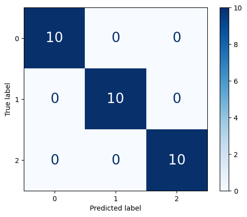

```python
from sklearn.metrics import confusion_matrix, ConfusionMatrixDisplay
from sklearn.metrics import accuracy_score, precision_score, recall_score, f1_score

# Get the logistic regression model with the best hyperparameters
best_model = grid_search.best_estimator_

# Predict iris plants test dataset results using the best model
test_predictions = best_model.predict(X_test_scaled)

# Generate confusion matrix
ax = ConfusionMatrixDisplay.from_predictions(y_test, test_predictions, cmap='Blues')
for data_point in ax.text_.ravel():
    data_point.set_fontsize(20)

# Evaluate the model
log_reg_accuracy = accuracy_score(y_test, test_predictions)
log_reg_precision = precision_score(y_test, test_predictions, average='macro')
log_reg_recall = recall_score(y_test, test_predictions, average='macro')
log_reg_f1 = f1_score(y_test, test_predictions, average='macro')

# Print the results
print(f'Test set accuracy: {log_reg_accuracy:.4f}')
print(f'Test set precision: {log_reg_precision:.4f}')
print(f'Test set recall: {log_reg_recall:.4f}')
print(f'Test set F1 score: {log_reg_f1:.4f}')
```

# 7 Model Comparison

The table below compares the three classification models that we have implemented on the Iris Plants dataset.

```python
import pandas as pd
import matplotlib.pyplot as plt

data = {
    'Classification Model': ['k-Nearest Neighbors (kNN)', 'Decision Tree', 'Logistic Regression'],
    'Best Hyperparameters': [
        'k=3, metric=euclidean',
        'max_depth: None, min_samples_split: 2',
        'C: 10, multi_class: multinomial, penalty: l2, solver: lbfgs'
    ],
    'Accuracy': [f'{knn_accuracy:.4f}', f'{dec_tree_accuracy:.4f}', f'{log_reg_accuracy:.4f}'],
    'Precision': [f'{knn_precision:.4f}', f'{dec_tree_precision:.4f}', f'{log_reg_precision:.4f}'],
    'Recall': [f'{knn_recall:.4f}', f'{dec_tree_recall:.4f}', f'{log_reg_recall:.4f}'],
    'F1 Score': [f'{knn_f1:.4f}', f'{dec_tree_f1:.4f}', f'{log_reg_f1:.4f}']
}

# Create and display dataframe
df = pd.DataFrame(data)
pd.set_option('display.max_colwidth', None)
df
```

|  | Classification Model | Best Hyperparameters | Accuracy | Precision | Recall | F1 Score |
| --- | --- | --- | --- | --- | --- | --- |
| 0 | k-Nearest Neighbors (kNN) | k=3, metric=euclidean | 0.9333 | 0.9444 | 0.9333 | 0.9327 |
| 1 | Decision Tree | max_depth: None, min_samples_split: 2 | 0.9333 | 0.9333 | 0.9333 | 0.9333 |
| 2 | Logistic Regression | C: 10, multi_class: multinomial, penalty: l2, solver: lbfgs | 1.0000 | 1.0000 | 1.0000 | 1.0000 |

From the results, K-Nearest Neighbours's evaluation metrics showed a 93.33% accuracy and recall, 94.44% for precision and 93.27% for F1 score, indicating that it did generally well classifying the Iris Plants dataset. Since KNN is a lazy learner, it is easy to understand and implement. However, one weakness is that since it uses distance metric in its algorithm, it may be computationally expensive for larger datasets.

For Decision Tree, it has a 93.33% for all 4 evaluation metrics. It shows that it does generally well in classifying the Iris Plants dataset as well. It does not require feature scaling however, it relies significantly on having good hyperparameters to produce accurate results and is sensitive to changes in the data.

Lastly, Logistic Regression does exceptionally well in classifying the Iris Plants dataset, obtaining a 100% on all 4 evaluation metrics. This shows that Logistic Regression is a good choice for classifying the Iris Plants dataset. The hyperparameter l2 helps to prevent the model from overfitting, which may have contributed to the model's good performance. Feature scaling had been applied to the dataset which could also contribute to the model's performance as it performs better with standardised features.

# 8 Conclusion

Overall, KNN is simple to understand and implement but becomes computationally expensive with larger datasets. Decision Tree offers interpretability but can become complex and prone to overfitting. Logistic Regression is outstanding with well-suited hyperparameters, but its sensitivity to hyperparameter and requirement for feature scaling add some complexity. As each model offers their own strengths and weaknesses, choosing which model to use for classification will depend on the dataset features and project requirement.

# 9 References and Resources

#### Dataset

- scikit-learn. (2024). *The Iris Dataset* [Online]. Available: https://scikit-learn.org/stable/auto_examples/datasets/plot_iris_dataset.html#sphx-glr-auto-examples-datasets-plot-iris-dataset-py
- Coursera Lecture 4.301 Cross-validation

#### K-Nearest Neighbours

- 'Machine Learning: K-Nearest Neighbours Classification' Lecture slides by Dr Tarapong Sreenuch
- K-Nearest Neighbours Classification Github lecture materials by Dr Tarapong Sreenuch
- scikit-learn. (2024). *1.6. Nearest Neighbors* [Online]. Available: https://scikit-learn.org/stable/modules/neighbors.html

#### Decision Tree

- 'Exercise: Decision Trees in sklearn' Github lecture exercise by Dr Tarapong Sreenuch
- scikit-learn. (2024). *1.10. Decision Trees* [Online]. Available: https://scikit-learn.org/stable/modules/tree.html
- scikit-learn. (2024). *DecisionTreeClassifier* [Online]. Available: https://scikit-learn.org/stable/modules/generated/sklearn.tree.DecisionTreeClassifier.html

#### Logistic Regression

- scikit-learn. (2024). *1.1. Linear Models* [Online]. Available: https://scikit-learn.org/stable/modules/linear_model.html#logistic-regression
- scikit-learn. (2024). *LogisticRegression* [Online]. Available: https://scikit-learn.org/stable/modules/generated/sklearn.linear_model.LogisticRegression.html